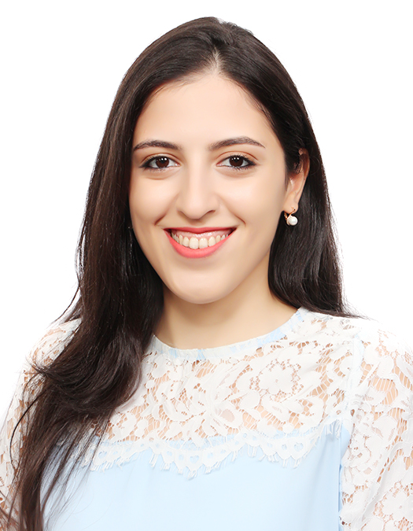

# Mouna Belaid

## Bio

I’m a passionate engineer in Statistics and Data Analysis, graduated from ESSAI and holding a research master’s degree in Data processing and Complexity of Living Systems from ENIT and Paris Descartes university.

I’m a Data Scientist based in Tunis, Tunisia. I’m working in the Banking industry with over 1 year of experience in Credit Risk management. I’m experienced in using data science tools like R, Python and SQL to build data solutions.

I’m always involved in extracting insights from data using data analytics tools, embracing my engineering mindset in order to do something innovative with every challenging dataset and coming up with reproducible and verifiable results. I’m skilled in deploying big data and building statistical models using advanced techniques.

I co-founder and co-organized a community of R users in Tunisia : R-Ladies Tunis. It’s a local chapter of a global open source community promoting gender inclusivity among R practitioners and learners, R-Ladies Global. I’m so happy for living such an experience and being part of a great R community. This experience is helping me to expand my network, meet amazing worldwide people, get inspired by them and improving my R skills.

## Education

**Doctoral School for Engineering Sciences and Techniques attached to the National Engineering School of Tunis ENIT** | Tunis, Tunisia

Research Master’s degree in Data Processing and Complexity of Living Systems | September 2018 - June 2019

**Paris Descartes University** | Paris, France

Comptuer Science Master’s degree | September 2018 - June 2019

**Higher School of Statistics and Data Analysis ESSAI-Tunis** | Tunis, Tunisia

Engineering Degree in Statistics and Data Analysis | September 2015 - June 2018

## Experience

**Arab International Bank of Tunisia BIAT, The Head Office, Credit Risk Department** | Data Scientist | June 2019 - Present